# Countries Happiness Index and Poverty Rate: Comparison and Correlation

Rain Sun, Aahaan Ruchir Sheth, Helen Song, Aarushi Jain

2023–29

# Introduction

The question of what variables contribute to a nation’s overall happiness is complex, yet one factor stands out as significant: the socioeconomic condition of the country, which is closely related to poverty rates. Though it is widely known that a sufficient, livable income is necessary for happiness, we wanted to specifically investigate how the strength of correlation between poverty rates and happiness changed as the socioeconomic status of a country increased. In our project, we plan to answer the question: does the correlation between a nation’s happiness and its poverty rates differ for developing versus developed countries? Through our analysis, we confirmed that the mean happiness between developing and developed countries differ, and that the happiness of developed countries is less correlated with poverty than that of developing countries.

# Background

-The dataset we used to quantify happiness was from the 2019 World Happiness Index dataset from the Gallup World Poll (https://www.kaggle.com/datasets/unsdsn/world-happiness?select=2019.csv). This dataset includes 156 countries and their happiness score from 2013-2016, a value obtained by asking respondents to rate their own current lives from a scale of 0 to 10, with a 0 being the worst possible life and 10 being the best possible life.

-To obtain poverty rate information, we extracted the extreme poverty rates for 162 countries from the the Median Income by Country dataset from wisevoter (https://wisevoter.com/country-rankings/poverty-rate-by-country/). The World Bank defines extreme poverty as living on less than $1.90 per day, measured at 2011 international prices (equivalent to $2.12 in 2018).

-We began by verifying whether our dataset confirmed that the overall happiness level for developed countries differed with that of developing countries by performing a two sample T-test. To categorize the countries by developing and developed, we used the UN’s classification dataset. To obtain our final dataset, we joined the happiness index, extreme poverty, and country classification dataset to examine the relationships between poverty and happiness index by developing and developed countries. We then performed a linear regression test on the relationship between poverty and happiness for both developing and developed countries.

## Analysis

A related introductory question was whether the happiness levels in developed and developing countries differed. We also wanted to observe the distribution of happiness between the two types of countries by categorizing the the index into “high” and “low” levels. We performed a two sample hypothesis test for the true mean happiness level between two types of countries, calculating the sample mean, sample standard deviation, and p-value.

### Comparing the Happiness Index in Developed vs Developing Countries

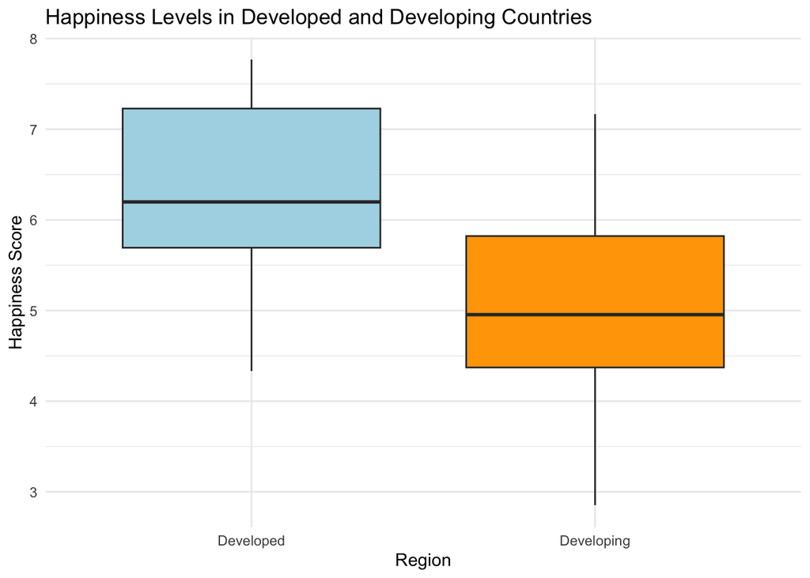

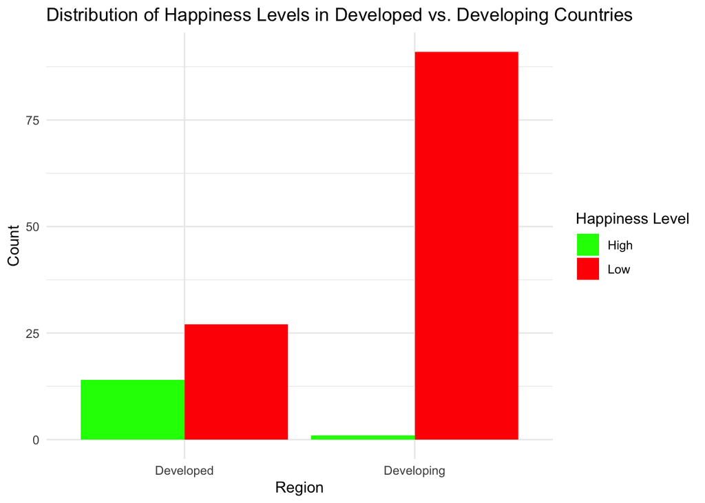

> We see that the mean for developed countries is clearly higher than that for developing countries. The body of the box plots have almost no overlapping regions, suggesting that the happiness levels between the two country categories are signifcantly different. Setting the happiness level of 7 as a boundary with an index more than or equal to 7 as a “high” happiness level and an index less than 7 as a “low” happiness level, we find that developing countries have a high percent countries with relatively low happiness level while developed countries have a higher percent of countries with relatively high happiness levels.

### Mean Hypothesis test

#### Population and Sample

- The population of developed countries is all the countries around the world that are categorized as developed countries
- The population of developing countries is all the countries around the world that are categorized as developing countries
- The sample of developed countries is the 41 developed countries in the world
- The sample of developing countries is the 92 developing countries in the world

#### Statistical Model

- Let $F$ be this unspecified distribution
- Let $\mu_1$ be the mean of happiness score of developing countries and $\mu_2$ be the mean of happuness score of developed countries
- Let $\sigma_1$ be the standard deviation of developing countries and $\sigma_2$ be the standard deviation of developed countries

#### State Hypothesis

$H_0: \mu_1 = \mu_2$ which is the true mean of developed and developing countries are the same $H_a: \mu_1 is\not = \mu_2$ which is the true mean of developed and developing countries are not the same

#### Test Statistics

$$T = \frac{\bar{X}_1 -
\bar{X}_2}{\sqrt{\frac{s_1^2}{n_1} + \frac{s_2^2}{n_2}}}$$

#### Interpretations

> Because the p-value = 0, we reject the null hypothesis. It is statistically significant that the true mean happiness score or level of developed and developing countries are different.

#### P-value visualization

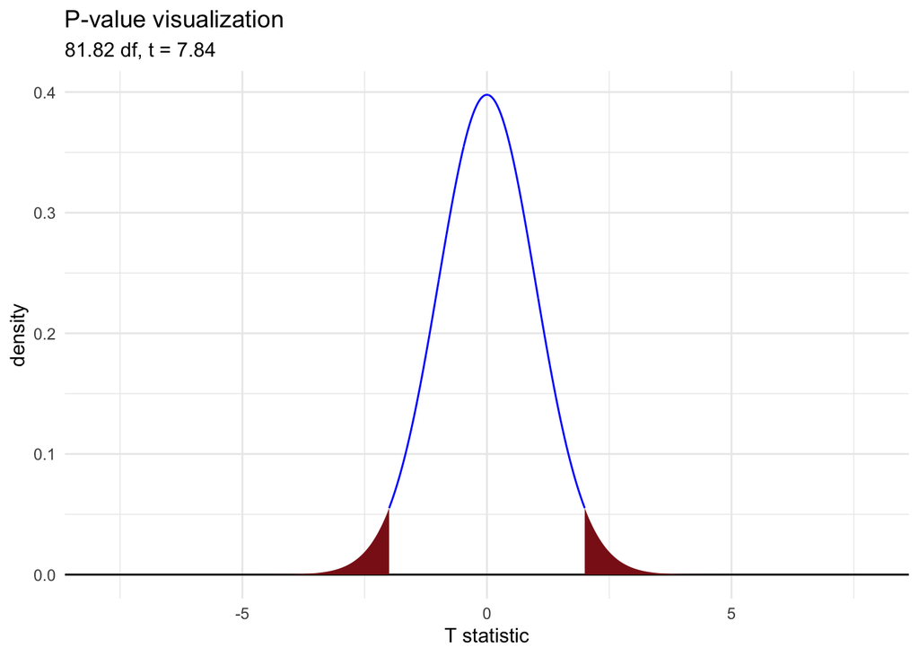

### Linear Regression for Poverty Rate and Happiness Index by Developed and Developing Countries

- The model will be built using a subset of $1:J$ splits:

$$y_i = \beta_0 + \sum_{j = 1}^J x_{ji}\beta_j + \varepsilon_i$$

- $y_i$ = The happiness index $i$
- $J$ = number of available splits
- $x_{ji}$ = the available split poverty rate for each country $i$’s interval $j$
- $\varepsilon_i$ = random error for each country $i$, assumed to satisfy $E(\varepsilon_i)=0$, and the $\varepsilon_i$’s are considered uncorrelated with a constant variance of $\sigma^2$.

#### Linear Model for Developing countries

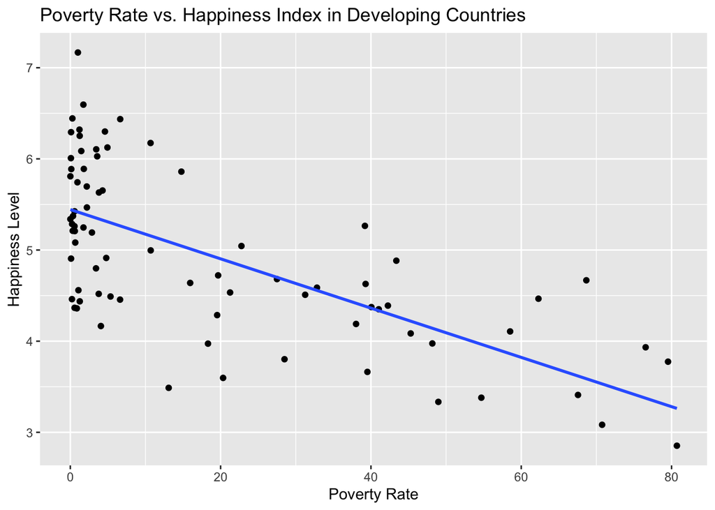

|  | Estimate | Std. Error | t value | Pr(>\|t\|) |
| --- | --- | --- | --- | --- |
| (Intercept) | 5.4440309 | 0.1014966 | 53.637573 | 0 |
| PovertyRate | -0.0270313 | 0.0033784 | -8.001315 | 0 |

```
##
## Call:
## lm(formula = Score ~ PovertyRate, data = developing)
##
## Residuals:
##     Min      1Q  Median      3Q     Max
## -1.6022 -0.4386 -0.0758  0.5423  1.7503
##
## Coefficients:
##              Estimate Std. Error t value Pr(>|t|)
## (Intercept)  5.444031   0.101497  53.638  < 2e-16 ***
## PovertyRate -0.027031   0.003378  -8.001 1.09e-11 ***
## ---
## Signif. codes:  0 '***' 0.001 '**' 0.01 '*' 0.05 '.' 0.1 ' ' 1
##
## Residual standard error: 0.6958 on 76 degrees of freedom
## Multiple R-squared:  0.4572, Adjusted R-squared:  0.4501
## F-statistic: 64.02 on 1 and 76 DF,  p-value: 1.095e-11
```

#### Linear Model for Developed countries

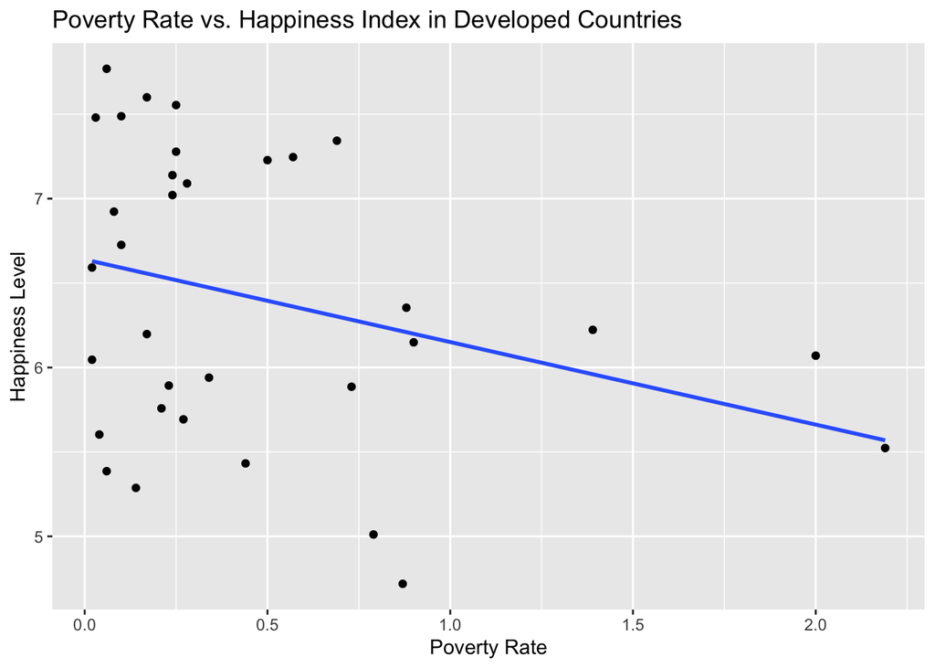

|  | Estimate | Std. Error | t value | Pr(>\|t\|) |
| --- | --- | --- | --- | --- |
| (Intercept) | 6.6395049 | 0.1909818 | 34.765119 | 0.0000000 |
| PovertyRate | -0.4888959 | 0.2726668 | -1.793016 | 0.0827333 |

```
##
## Call:
## lm(formula = Score ~ PovertyRate, data = developed)
##
## Residuals:
##     Min      1Q  Median      3Q     Max
## -1.4952 -0.6341  0.1354  0.7607  1.1588
##
## Coefficients:
##             Estimate Std. Error t value Pr(>|t|)
## (Intercept)   6.6395     0.1910  34.765   <2e-16 ***
## PovertyRate  -0.4889     0.2727  -1.793   0.0827 .
## ---
## Signif. codes:  0 '***' 0.001 '**' 0.01 '*' 0.05 '.' 0.1 ' ' 1
##
## Residual standard error: 0.8244 on 31 degrees of freedom
## Multiple R-squared:  0.09396,    Adjusted R-squared:  0.06474
## F-statistic: 3.215 on 1 and 31 DF,  p-value: 0.08273
```

## Discussion

- An important takeaway is the general trend between poverty and happiness levels as economic conditions and quality of life improves. Our data analysis shows that poverty levels have a stronger impact on happiness levels in developing countries.
- One possible explanation is that individuals from developing countries struggle more with fulfilling basic needs such as sufficient food, clean water, and healthcare. While income is highly correlated with happiness levels, its influence becomes less pronounced as the wealth of a country increases. Beyond income levels that allow individuals to meet their basic needs, additional factors such as social relationships, career fulfillment, self-esteem, and psychological wellbeing become larger players in what contributes to happiness. This concept aligns with Maslow’s hierarchy of needs, a psychological theory which posits that people primarily seek to satisfy their physiological, basic needs first, and then fulfill higher level needs such as psychological, social belonging, and self-actualization needs.
- Future directions could include investigating the income threshold at which increasing income yields diminishing returns in happiness and comparing our results for developing versus developed countries. One potential shortcoming in our analysis is using the extreme poverty measure; extreme poverty may not always directly correlate with overall poverty or account for aspects such as a country’s overall income or income inequality. Further research could also investigate other factors such as income levels, income inequality, and general poverty rates in relation to a nation’s happiness.